# HAT-GOE-Monitor-Code

#### 9.6.7.2 *** Sort Mean Cover Treated plot no grass

```r
colnames(oakhaven_2025_cover_treat_sp_mean)
```

```
## [1] "Species"            "meanPercentCover"   "Native_or_Invasive"
```

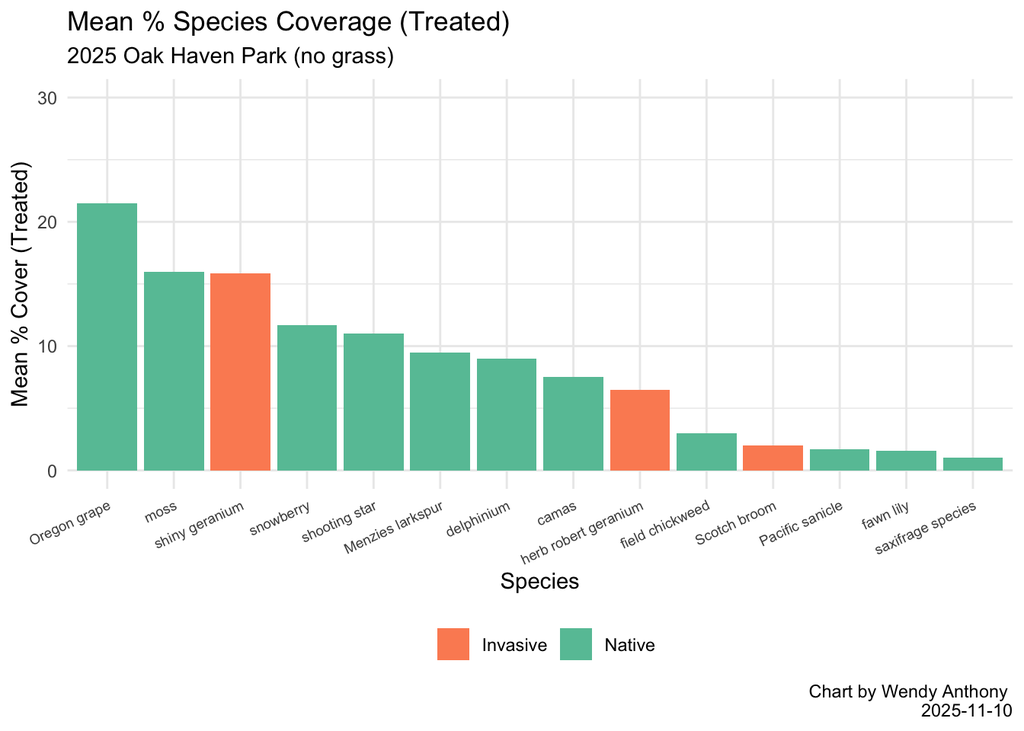

```r
# create custom colour-blind-friendly palette
custom_colours <- c("Invasive" = "#fc8d62",
                    "Native" = "#66c2a5",
                    "MixedGrass" = "#8da0cb")

oakhaven_2025_cover_treat_sp_mean_plot_nograss_sort  <- oakhaven_2025_cover_treat_sp_mean %>% arrange(desc(meanPercentCover))  %>%
  filter(Native_or_Invasive != "MixedGrass") %>%
  # updates Site with new arrangement
   mutate(Species = factor(Species, levels = Species)) %>%

  ggplot(
      aes(x = Species, y = meanPercentCover, fill = Native_or_Invasive)) +
      ylim(0, 30) +
      geom_bar(stat = "identity") +
      scale_fill_manual(values = custom_colours, name = "Native/Invasive") +
      theme_minimal() + #get rid of grey background and tick marks
      theme(legend.position="bottom") +
      theme(legend.title=element_blank()) +
      theme(axis.text.x = element_text(angle = 25, vjust = 1, hjust=1, size = 7)) +
      labs(title='Mean % Species Coverage (Treated)',
           subtitle='2025 Oak Haven Park (no grass)',
           caption = "Chart by Wendy Anthony \n 2025-11-10",
           y = "Mean % Cover (Treated)")
oakhaven_2025_cover_treat_sp_mean_plot_nograss_sort
```

```r
# ggsave(filename = paste0("images/oakhaven_2025_cover_treat_sp_mean_plot_nograss_sort_barplot_", format(Sys.time(), "%Y-%m-%d_%H.%M.%S"),".png"), oakhaven_2025_cover_treat_sp_mean_plot_nograss_sort)

# ggsave("images/oakhaven_2025_cover_treat_sp_mean_plot_nograss_sort_barplot.png", oakhaven_2025_cover_treat_sp_mean_plot_nograss_sort)
```

### 9.6.8 *** Combine 2 Bar Treatment plots

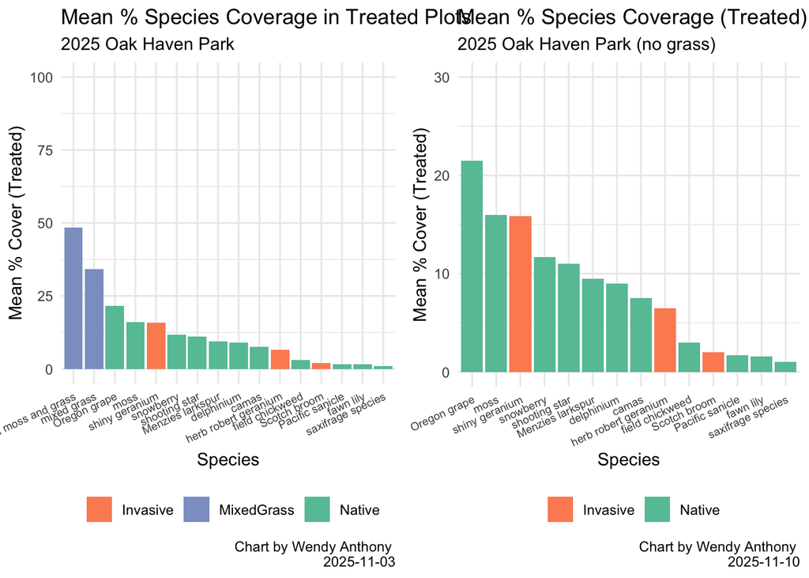

```r
# library(gridExtra)

combine_oakhaven_2025_cover_treat_sp_mean_plot_grassnograss_sort <- grid.arrange(arrangeGrob(oakhaven_2025_cover_treat_sp_mean_plot_sort, oakhaven_2025_cover_treat_sp_mean_plot_nograss_sort, ncol = 2))
```

```r
# ggsave(filename = paste0("images/combine_oakhaven_2025_cover_treat_sp_mean_plot_grassnograss_sort_", format(Sys.time(), "%Y-%m-%d_%H.%M"),".png"), combine_oakhaven_2025_cover_treat_sp_mean_plot_grassnograss_sort)
```

### 9.6.9 Mean Cover Untreated plot

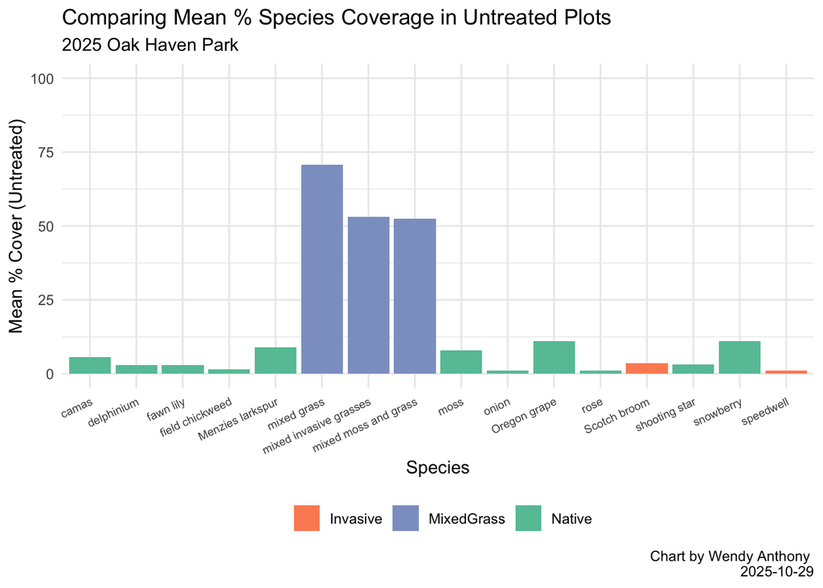

```r
# create custom colour-blind-friendly palette
custom_colours <- c("Invasive" = "#fc8d62",
                    "Native" = "#66c2a5",
                    "MixedGrass" = "#8da0cb")

oakhaven_2025_cover_treat_sp_mean_plot  <- ggplot(oakhaven_2025_cover_untreat_sp_mean,
      aes(x = Species, y = meanPercentCover, fill = Native_or_Invasive)) +
      ylim(0, 100) +
      geom_bar(stat = "identity") +
      scale_fill_manual(values = custom_colours, name = "Native/Invasive") +
      theme_minimal() + #get rid of grey background and tick marks
      theme(legend.position="bottom") +
      theme(legend.title=element_blank()) +
      theme(axis.text.x = element_text(angle = 25, vjust = 1, hjust=1, size = 7)) +
      labs(title='Comparing Mean % Species Coverage in Untreated Plots',
           subtitle='2025 Oak Haven Park',
           caption = "Chart by Wendy Anthony \n 2025-10-29",
           y = "Mean % Cover (Untreated)")

oakhaven_2025_cover_treat_sp_mean_plot
```

```r
# ggsave(filename = paste0("images/oakhaven_2025_cover_treat_sp_mean_plot_", format(Sys.time(), "%Y-%m-%d_%H.%M"),".png"), oakhaven_2025_cover_treat_sp_mean_plot)
```

### 9.6.10 Mean Cover Untreated plot no grass

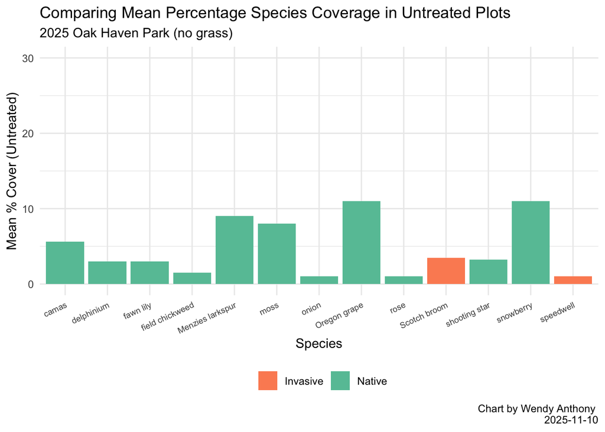

```r
# create custom colour-blind-friendly palette
custom_colours <- c("Invasive" = "#fc8d62",
                    "Native" = "#66c2a5",
                    "MixedGrass" = "#8da0cb")

oakhaven_2025_cover_untreat_sp_mean_nograss_plot  <- oakhaven_2025_cover_untreat_sp_mean %>% filter(Native_or_Invasive != "MixedGrass") %>%
ggplot(
      aes(x = Species, y = meanPercentCover, fill = Native_or_Invasive)) +
      ylim(0, 30) +
      geom_bar(stat = "identity") +
      scale_fill_manual(values = custom_colours, name = "Native/Invasive") +
      theme_minimal() + #get rid of grey background and tick marks
      theme(legend.position ="bottom") +
      theme(legend.title=element_blank()) +
      theme(axis.text.x = element_text(angle = 25, vjust = 1, hjust=1, size = 7)) +
      labs(title='Comparing Mean Percentage Species Coverage in Untreated Plots',
           subtitle='2025 Oak Haven Park (no grass)',
           caption = "Chart by Wendy Anthony \n 2025-11-10",
           y = "Mean % Cover (Untreated)")

oakhaven_2025_cover_untreat_sp_mean_nograss_plot
```

```r
# ggsave(filename = paste0("images/oakhaven_2025_cover_untreat_sp_mean_nograss_plot_", format(Sys.time(), "%Y-%m-%d_%H.%M"),".png"), oakhaven_2025_cover_untreat_sp_mean_nograss_plot)
```

### 9.6.11 ** Untreated

- sorted by highest mean % cover
- see next chart for grouped by native/inv

```r
colnames(OH_2025_perc_cover_treat_mean_merge)
```

```
## [1] "Species"            "t_meanPercentCover" "u_meanPercentCover"
## [4] "Native_or_Invasive"
```

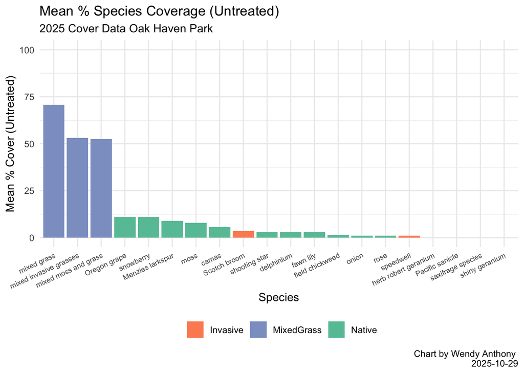

```r
# create custom colour-blind-friendly palette
custom_colours <- c("Invasive" = "#fc8d62",
                    "Native" = "#66c2a5",
                    "MixedGrass" = "#8da0cb")

OH_2025_perc_cover_untreat_mean_merge_plot_sort <- OH_2025_perc_cover_treat_mean_merge %>% arrange(desc(u_meanPercentCover)) %>%
  # updates Site with new arrangement
   mutate(Species = factor(Species, levels = Species)) %>%

  ggplot(
                    aes(x = Species, y = u_meanPercentCover, fill = Native_or_Invasive)) +
                      ylim(0, 100) +
                    #geom_bar(stat = "identity", fill = "seagreen") +
                    geom_bar(stat = "identity") +
                    scale_fill_manual(values = custom_colours) +
                    theme_minimal() + #get rid of grey background and tick marks
                    theme(legend.position ="bottom") +
                    theme(legend.title=element_blank()) +
                    theme(axis.text.x = element_text(angle = 25, vjust = 1, hjust=1, size = 7)) +
                    labs(title='Mean % Species Coverage (Untreated)',
                      subtitle='2025 Cover Data Oak Haven Park',
                      caption = "Chart by Wendy Anthony \n 2025-10-29",
                      y = "Mean % Cover (Untreated)",
                      # Legend Title
                    fill = "Native or Invasive")

OH_2025_perc_cover_untreat_mean_merge_plot_sort
```

```r
# ggsave(filename = paste0("images/OH_2025_perc_cover_untreat_mean_merge_plot_sort_barplot_", format(Sys.time(), "%Y-%m-%d_%H.%M"),".png"), OH_2025_perc_cover_untreat_mean_merge_plot_sort)

#ggsave("images/OH_2025_perc_cover_untreat_mean_merge_plot_sort_barplot.png", OH_2025_perc_cover_untreat_mean_merge_plot_sort)
```

### 9.6.12 ** Untreated no grass

- sorted by highest mean % cover
- see next chart for grouped by native/inv

```r
colnames(OH_2025_perc_cover_treat_mean_merge)
```

```
## [1] "Species"            "t_meanPercentCover" "u_meanPercentCover"
## [4] "Native_or_Invasive"
```

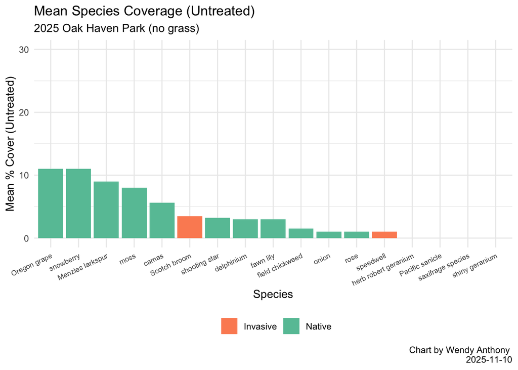

```r
# create custom colour-blind-friendly palette
custom_colours <- c("Invasive" = "#fc8d62",
                    "Native" = "#66c2a5",
                    "MixedGrass" = "#8da0cb")

OH_2025_perc_cover_untreat_mean_merge_plot_nograss_sort <- OH_2025_perc_cover_treat_mean_merge %>% arrange(desc(u_meanPercentCover)) %>% filter(Native_or_Invasive != "MixedGrass") %>%
  # updates Site with new arrangement
   mutate(Species = factor(Species, levels = Species)) %>%

  ggplot(
                    aes(x = Species, y = u_meanPercentCover, fill = Native_or_Invasive)) +
                      ylim(0, 30) +
                    #geom_bar(stat = "identity", fill = "seagreen") +
                    geom_bar(stat = "identity") +
                    scale_fill_manual(values = custom_colours) +
                    theme_minimal() + #get rid of grey background and tick marks
                    theme(legend.position ="bottom") +
                    theme(legend.title=element_blank()) +
                    theme(axis.text.x = element_text(angle = 25, vjust = 1, hjust=1, size = 7)) +
                    labs(title='Mean Species Coverage (Untreated)',
                      subtitle='2025 Oak Haven Park (no grass)',
                      caption = "Chart by Wendy Anthony \n 2025-11-10",
                      y = "Mean % Cover (Untreated)",
                      # Legend Title
          fill = "Native or Invasive")
OH_2025_perc_cover_untreat_mean_merge_plot_nograss_sort
```

```r
ggsave("images/OH_2025_perc_cover_untreat_mean_merge_plot_nograss_sort_barplot.png", OH_2025_perc_cover_untreat_mean_merge_plot_nograss_sort)
```

### 9.6.13 *** Combine 2 Bar Untreated plots sorted grass no grass

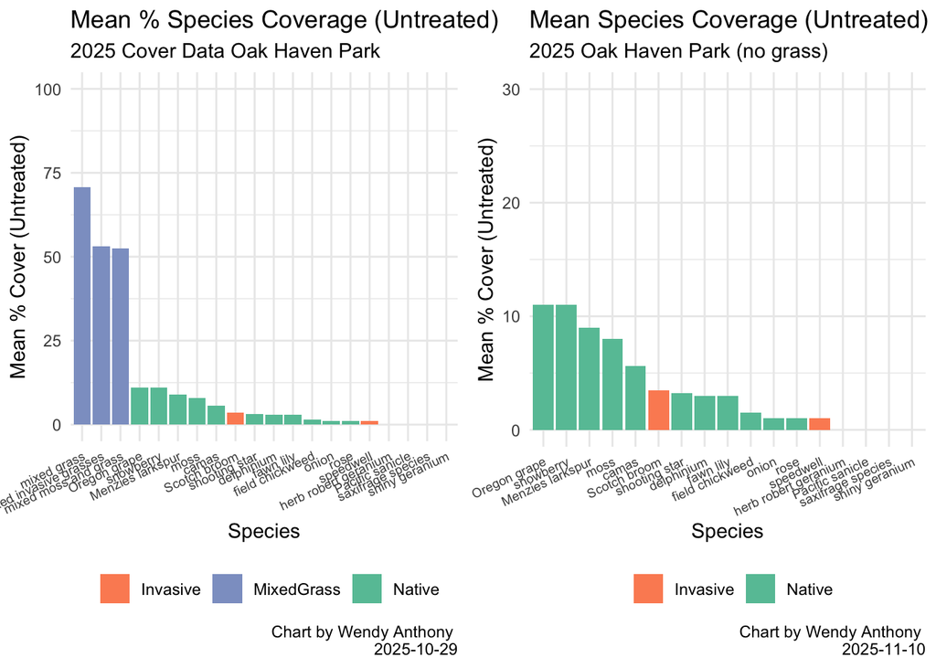

```r
# library(gridExtra)

combine_OH_2025_perc_cover_untreat_mean_merge_plot_nograss_sort <- grid.arrange(arrangeGrob(OH_2025_perc_cover_untreat_mean_merge_plot_sort,
OH_2025_perc_cover_untreat_mean_merge_plot_nograss_sort, ncol = 2))
```

```r
# ggsave(filename = paste0("images/combine_OH_2025_perc_cover_untreat_mean_merge_plot_nograss_sort_", format(Sys.time(), "%Y-%m-%d_%H.%M"),".png"), combine_OH_2025_perc_cover_untreat_mean_merge_plot_nograss_sort)
```

### 9.6.14 *** Combine 2 Bar Treatment plots

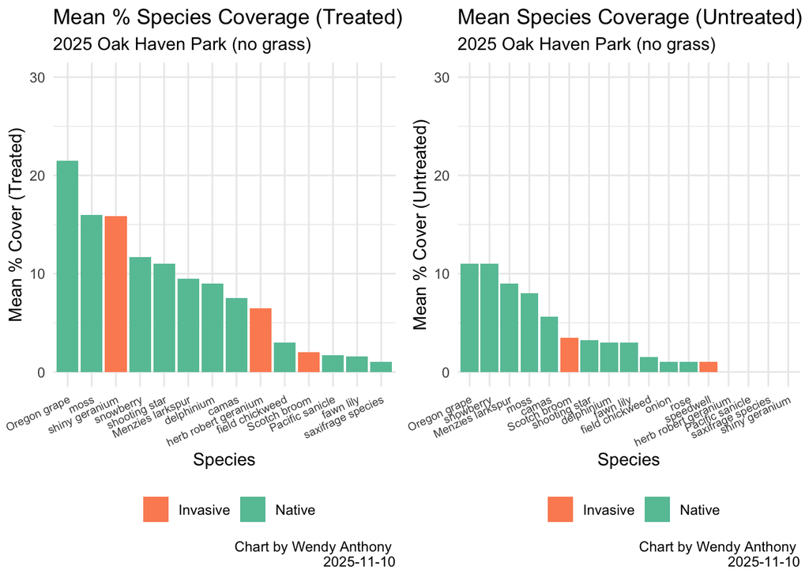

```r
# library(gridExtra)

combine_oakhaven_2025_cover_tr_untr_mean_bar_nograss_Plot <- grid.arrange(oakhaven_2025_cover_treat_sp_mean_plot_nograss_sort, OH_2025_perc_cover_untreat_mean_merge_plot_nograss_sort, ncol = 2)
```

```r
# ggsave(filename = paste0("images/combine_oakhaven_2025_cover_tr_untr_mean_bar_dodge_Plot_", format(Sys.time(), "%Y-%m-%d_%H.%M"),".png"), combine_oakhaven_2025_cover_tr_untr_mean_bar_dodge_Plot)

# ggsave("images/combine_oakhaven_2025_cover_tr_untr_mean_bar_dodge_Plot.png", combine_oakhaven_2025_cover_tr_untr_mean_bar_dodge_Plot)
```

### 9.6.15 ** Grouped Sorted Untreated

- grouped by native/inv

```r
colnames(OH_2025_perc_cover_treat_mean_merge)
```

```
## [1] "Species"            "t_meanPercentCover" "u_meanPercentCover"
## [4] "Native_or_Invasive"
```

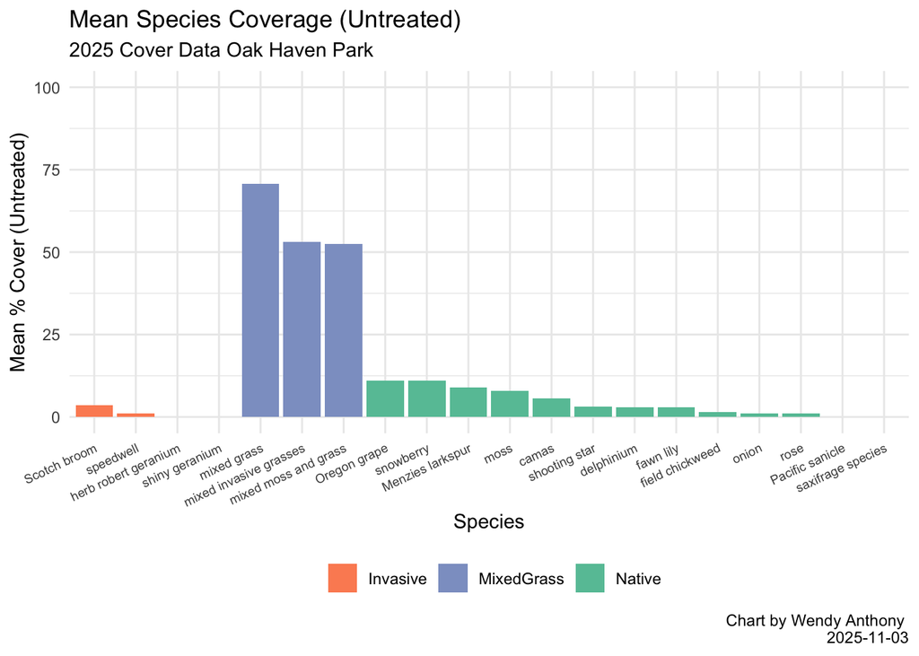

```r
# create custom colour-blind-friendly palette
custom_colours <- c("Invasive" = "#fc8d62",
                    "Native" = "#66c2a5",
                    "MixedGrass" = "#8da0cb")

OH_2025_perc_cover_untreat_mean_merge_plot_sort_group <- OH_2025_perc_cover_treat_mean_merge %>%
  group_by(Native_or_Invasive) %>%
  arrange(desc(u_meanPercentCover)) %>%
  # updates Site with new arrangement
   mutate(Species = factor(Species, levels = Species)) %>%

  ggplot(
                    aes(x = Species, y = u_meanPercentCover, fill = Native_or_Invasive)) +
                      ylim(0, 100) +
                    #geom_bar(stat = "identity", fill = "seagreen") +
                    geom_bar(stat = "identity") +
                    scale_fill_manual(values = custom_colours) +
                    theme_minimal() + #get rid of grey background and tick marks
                    theme(legend.position ="bottom") +
                    theme(legend.title=element_blank()) +
                    theme(axis.text.x = element_text(angle = 25, vjust = 1, hjust=1, size = 7)) +
                    labs(title='Mean Species Coverage (Untreated)',
                      subtitle='2025 Cover Data Oak Haven Park',
                      caption = "Chart by Wendy Anthony \n 2025-11-03",
                      y = "Mean % Cover (Untreated)",
                      # Legend Title
          fill = "Native or Invasive")
OH_2025_perc_cover_untreat_mean_merge_plot_sort_group
```

```r
# ggsave(filename = paste0("images/OH_2025_perc_cover_untreat_mean_merge_plot_sort_group_barplot_", format(Sys.time(), "%Y-%m-%d_%H.%M"),".png"), OH_2025_perc_cover_untreat_mean_merge_plot_sort_group)

# ggsave("images/OH_2025_perc_cover_untreat_mean_merge_plot_sort_group_barplot.png", OH_2025_perc_cover_untreat_mean_merge_plot_sort_group)
```

### 9.6.16 ** Grouped Sorted Untreated no grass

- grouped by native/inv

```r
colnames(OH_2025_perc_cover_treat_mean_merge)
```

```
## [1] "Species"            "t_meanPercentCover" "u_meanPercentCover"
## [4] "Native_or_Invasive"
```

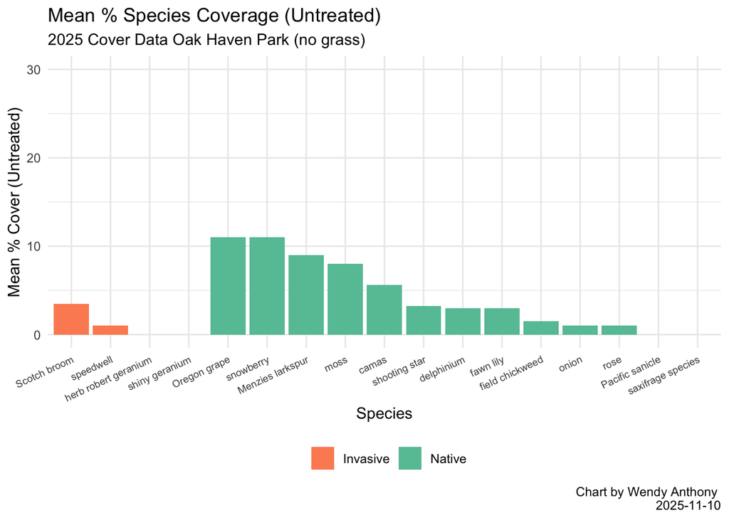

```r
# create custom colour-blind-friendly palette
custom_colours <- c("Invasive" = "#fc8d62",
                    "Native" = "#66c2a5",
                    "MixedGrass" = "#8da0cb")

OH_2025_perc_cover_untreat_mean_merge_plot_sort_group_nograss <- OH_2025_perc_cover_treat_mean_merge %>%
  filter(Native_or_Invasive != "MixedGrass") %>%
  group_by(Native_or_Invasive) %>%
  arrange(desc(u_meanPercentCover)) %>%
  # updates Site with new arrangement
   mutate(Species = factor(Species, levels = Species)) %>%

  ggplot(
                    aes(x = Species, y = u_meanPercentCover, fill = Native_or_Invasive)) +
                      ylim(0, 30) +
                    #geom_bar(stat = "identity", fill = "seagreen") +
                    geom_bar(stat = "identity") +
                    scale_fill_manual(values = custom_colours) +
                    theme_minimal() + #get rid of grey background and tick marks
                    theme(legend.position ="bottom") +
                    theme(legend.title=element_blank()) +
                    theme(axis.text.x = element_text(angle = 25, vjust = 1, hjust=1, size = 7)) +
                    labs(title='Mean % Species Coverage (Untreated)',
                      subtitle='2025 Cover Data Oak Haven Park (no grass)',
                      caption = "Chart by Wendy Anthony \n 2025-11-10",
                      y = "Mean % Cover (Untreated)",
                      # Legend Title
          fill = "Native or Invasive")
OH_2025_perc_cover_untreat_mean_merge_plot_sort_group_nograss
```

```r
# ggsave(filename = paste0("images/OH_2025_perc_cover_untreat_mean_merge_plot_sort_group_nograss_barplot.png/_", format(Sys.time(), "%Y-%m-%d_%H.%M"),".png"), OH_2025_perc_cover_untreat_mean_merge_plot_sort_group_nograss)

# ggsave("images/OH_2025_perc_cover_untreat_mean_merge_plot_sort_group_nograss_barplot.png", OH_2025_perc_cover_untreat_mean_merge_plot_sort_group_nograss)
```

### 9.6.17 **** Combine 2 Bar Untreated plots sorted grass no grass

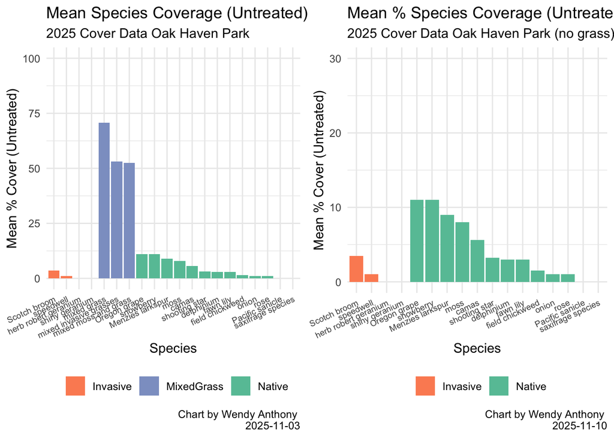

```r
# library(gridExtra)

combine_OH_2025_perc_cover_untreat_mean_merge_plot_grassnograss_sort <- grid.arrange(arrangeGrob(OH_2025_perc_cover_untreat_mean_merge_plot_sort_group, OH_2025_perc_cover_untreat_mean_merge_plot_sort_group_nograss,
 ncol = 2))
```

```r
# ggsave(filename = paste0("images/combine_OH_2025_perc_cover_untreat_mean_merge_plot_grassnograss_sort_", format(Sys.time(), "%Y-%m-%d_%H.%M"),".png"), combine_OH_2025_perc_cover_untreat_mean_merge_plot_grassnograss_sort)
```

#### 9.6.17.1 *** Grouped Sort Mean Cover Treated plot

- as per `file:///Users/wanthony/Documents/R/Test-Shiny-GOE-Monitor/TEST-GOE-Monitor.html#48_Violin_Subregion_by_Exotic_species` - e.g. group_by(Native_or_Invasive) %>%

```r
colnames(oakhaven_2025_cover_treat_sp_mean)
```

```
## [1] "Species"            "meanPercentCover"   "Native_or_Invasive"
```

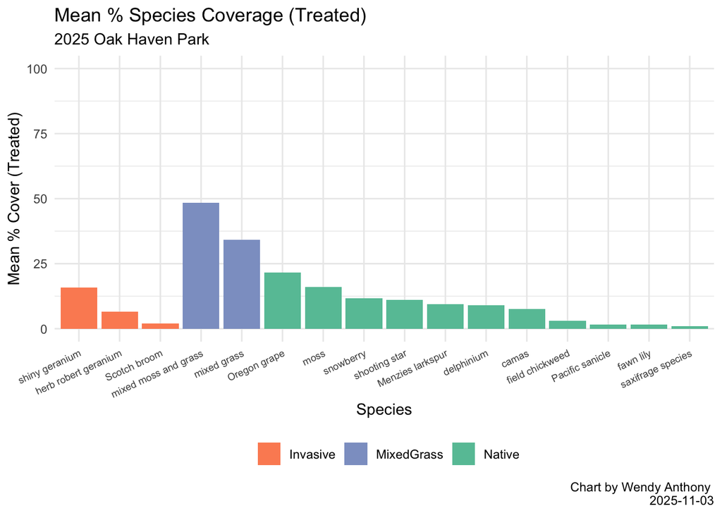

```r
# create custom colour-blind-friendly palette
custom_colours <- c("Invasive" = "#fc8d62",
                    "Native" = "#66c2a5",
                    "MixedGrass" = "#8da0cb")

oakhaven_2025_cover_treat_sp_mean_plot_sort_group  <- oakhaven_2025_cover_treat_sp_mean %>%
  group_by(Native_or_Invasive) %>%
  arrange(desc(meanPercentCover)) %>%
  # updates Site with new arrangement
   mutate(Species = factor(Species, levels = Species)) %>%

  ggplot(
      aes(x = Species, y = meanPercentCover, fill = Native_or_Invasive)) +
      ylim(0, 100) +
      geom_bar(stat = "identity") +
      scale_fill_manual(values = custom_colours, name = "Native/Invasive") +
      theme_minimal() + #get rid of grey background and tick marks
      theme(legend.position ="bottom") +
      theme(legend.title=element_blank()) +
      theme(axis.text.x = element_text(angle = 25, vjust = 1, hjust=1, size = 7)) +
      labs(title='Mean % Species Coverage (Treated)',
           subtitle='2025 Oak Haven Park',
           caption = "Chart by Wendy Anthony \n 2025-11-03",
           y = "Mean % Cover (Treated)")
oakhaven_2025_cover_treat_sp_mean_plot_sort_group
```

```r
# ggsave(filename = paste0("images/oakhaven_2025_cover_treat_sp_mean_plot_sort_group_barplot_", format(Sys.time(), "%Y-%m-%d_%H.%M"),".png"), oakhaven_2025_cover_treat_sp_mean_plot_sort_group)

# ggsave("images/oakhaven_2025_cover_treat_sp_mean_plot_sort_group_barplot.png", oakhaven_2025_cover_treat_sp_mean_plot_sort_group)
```

#### 9.6.17.2 **** Grouped Sort Mean Cover Treated plot no grass

- as per `file:///Users/wanthony/Documents/R/Test-Shiny-GOE-Monitor/TEST-GOE-Monitor.html#48_Violin_Subregion_by_Exotic_species` - e.g. group_by(Native_or_Invasive) %>%

```r
colnames(oakhaven_2025_cover_treat_sp_mean)
```

```
## [1] "Species"            "meanPercentCover"   "Native_or_Invasive"
```

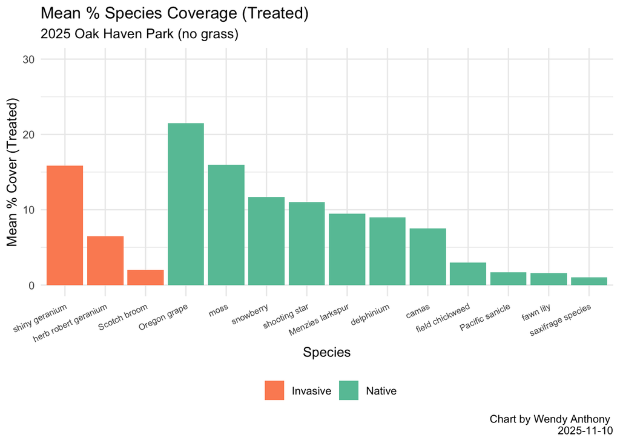

```r
# create custom colour-blind-friendly palette
custom_colours <- c("Invasive" = "#fc8d62",
                    "Native" = "#66c2a5",
                    "MixedGrass" = "#8da0cb")

oakhaven_2025_cover_treat_sp_mean_plot_sort_group_nograss  <- oakhaven_2025_cover_treat_sp_mean %>% filter(Native_or_Invasive != "MixedGrass") %>%
  group_by(Native_or_Invasive) %>%
  arrange(desc(meanPercentCover)) %>%
  # updates Site with new arrangement
   mutate(Species = factor(Species, levels = Species)) %>%

  ggplot(
      aes(x = Species, y = meanPercentCover, fill = Native_or_Invasive)) +
      ylim(0, 30) +
      geom_bar(stat = "identity") +
      scale_fill_manual(values = custom_colours, name = "Native/Invasive") +
      theme_minimal() + #get rid of grey background and tick marks
      theme(legend.position ="bottom") +
      theme(legend.title=element_blank()) +
      theme(axis.text.x = element_text(angle = 25, vjust = 1, hjust=1, size = 7)) +
      labs(title='Mean % Species Coverage (Treated)',
           subtitle='2025 Oak Haven Park (no grass)',
           caption = "Chart by Wendy Anthony \n 2025-11-10",
           y = "Mean % Cover (Treated)")

oakhaven_2025_cover_treat_sp_mean_plot_sort_group_nograss
```

```r
# ggsave(filename = paste0("images/oakhaven_2025_cover_treat_sp_mean_plot_sort_group_nograss_barplot.png_", format(Sys.time(), "%Y-%m-%d_%H.%M"),".png"), oakhaven_2025_cover_treat_sp_mean_plot_sort_group_nograss)

# ggsave("images/oakhaven_2025_cover_treat_sp_mean_plot_sort_group_nograss_barplot.png", oakhaven_2025_cover_treat_sp_mean_plot_sort_group_nograss)
```

### 9.6.18 **** Combine 2 Bar Treated plots sorted grass no grass

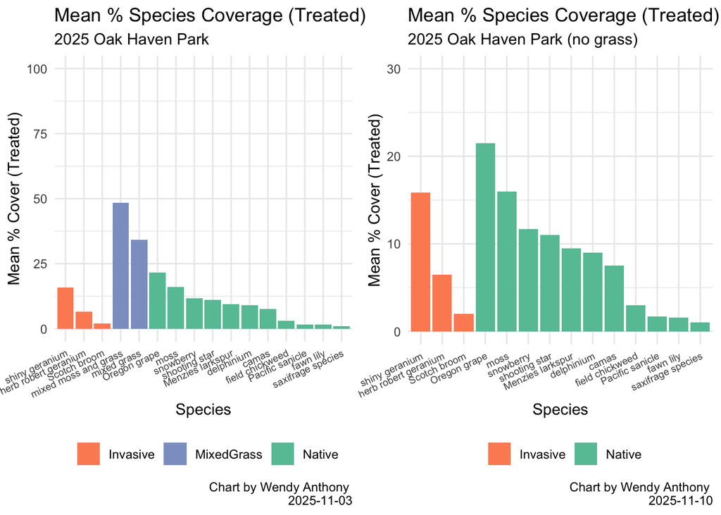

```r
# library(gridExtra)

combine_oakhaven_2025_cover_treat_sp_mean_plot_sort_group_nograss_barplot <- grid.arrange(arrangeGrob(oakhaven_2025_cover_treat_sp_mean_plot_sort_group,
oakhaven_2025_cover_treat_sp_mean_plot_sort_group_nograss, ncol = 2))
```

```r
# ggsave(filename = paste0("images/combine_oakhaven_2025_cover_treat_sp_mean_plot_sort_group_nograss_barplot_", format(Sys.time(), "%Y-%m-%d_%H.%M"),".png"), combine_oakhaven_2025_cover_treat_sp_mean_plot_sort_group_nograss_barplot)
```

### 9.6.19 **** Combine 2 Bar sorted Treatment plots

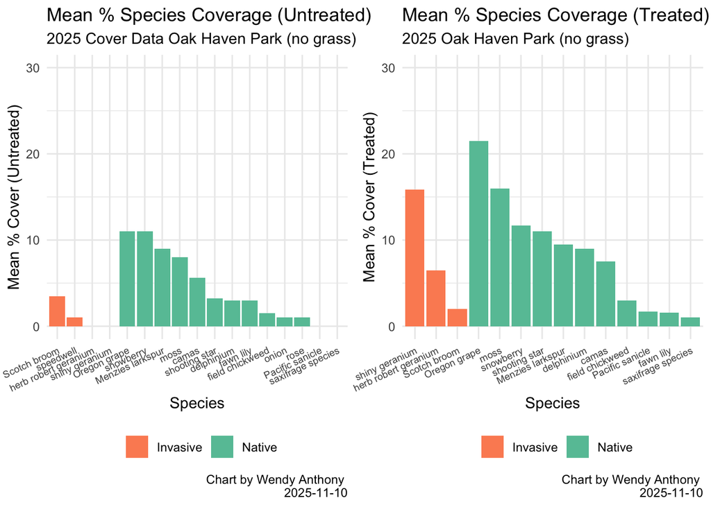

```r
# library(gridExtra)

combine_oakhaven_2025_cover_tr_untr_mean_bar_nograss_sorted_Plot <- grid.arrange(OH_2025_perc_cover_untreat_mean_merge_plot_sort_group_nograss, oakhaven_2025_cover_treat_sp_mean_plot_sort_group_nograss, ncol = 2)
```

```r
# ggsave(filename = paste0("images/combine_oakhaven_2025_cover_tr_untr_mean_bar_nograss_sorted_Plot_", format(Sys.time(), "%Y-%m-%d_%H.%M"),".png"), combine_oakhaven_2025_cover_tr_untr_mean_bar_nograss_sorted_Plot)

# ggsave("images/combine_oakhaven_2025_cover_tr_untr_mean_bar_nograss_sorted_Plot.png", combine_oakhaven_2025_cover_tr_untr_mean_bar_nograss_sorted_Plot)
```

### 9.6.20 ** Untreated

- ?? can these be sorted by native/inv

```r
colnames(OH_2025_perc_cover_treat_mean_merge)
```

```
## [1] "Species"            "t_meanPercentCover" "u_meanPercentCover"
## [4] "Native_or_Invasive"
```

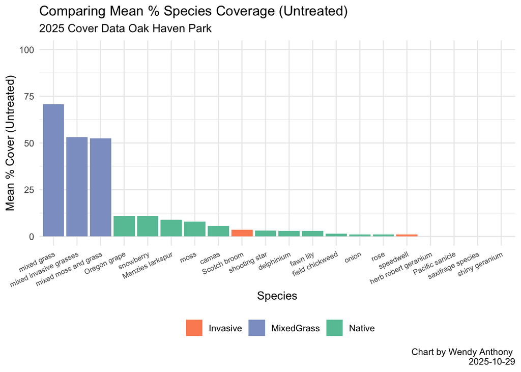

```r
# create custom colour-blind-friendly palette
custom_colours <- c("Invasive" = "#fc8d62",
                    "Native" = "#66c2a5",
                    "MixedGrass" = "#8da0cb")

OH_2025_perc_cover_untreat_mean_merge_plot_sort <- OH_2025_perc_cover_treat_mean_merge %>% arrange(desc(u_meanPercentCover)) %>%
  # updates Site with new arrangement
   mutate(Species = factor(Species, levels = Species)) %>%

  ggplot(
                    aes(x = Species, y = u_meanPercentCover, fill = Native_or_Invasive)) +
                      ylim(0, 100) +
                    #geom_bar(stat = "identity", fill = "seagreen") +
                    geom_bar(stat = "identity") +
                    scale_fill_manual(values = custom_colours) +
                    theme_minimal() + #get rid of grey background and tick marks
                    theme(legend.position ="bottom") +
                    theme(legend.title=element_blank()) +
                    theme(axis.text.x = element_text(angle = 25, vjust = 1, hjust=1, size = 7)) +
                    labs(title='Comparing Mean % Species Coverage (Untreated)',
                      subtitle='2025 Cover Data Oak Haven Park',
                      caption = "Chart by Wendy Anthony \n 2025-10-29",
                      y = "Mean % Cover (Untreated)",
                      # Legend Title
          fill = "Native or Invasive")
OH_2025_perc_cover_untreat_mean_merge_plot_sort
```

```r
# ggsave(filename = paste0("images/OH_2025_perc_cover_untreat_mean_merge_plot_sort_barplot_", format(Sys.time(), "%Y-%m-%d_%H.%M"),".png"), OH_2025_perc_cover_untreat_mean_merge_plot_sort)

# ggsave("images/OH_2025_perc_cover_untreat_mean_merge_plot_sort_barplot.png", OH_2025_perc_cover_untreat_mean_merge_plot_sort)
```

### 9.6.21 ** Untreated no grass

- ?? can these be sorted by native/inv

```r
colnames(OH_2025_perc_cover_treat_mean_merge)
```

```
## [1] "Species"            "t_meanPercentCover" "u_meanPercentCover"
## [4] "Native_or_Invasive"
```

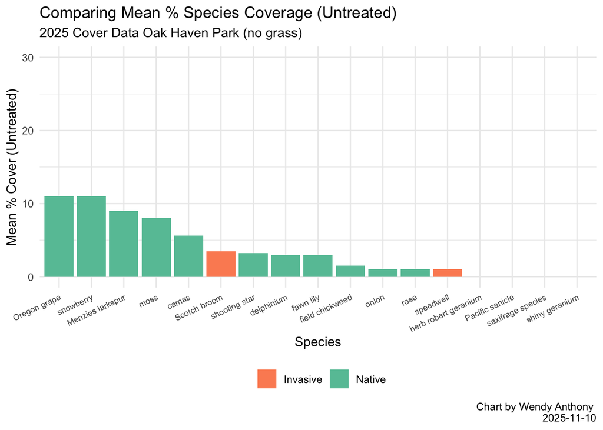

```r
# create custom colour-blind-friendly palette
custom_colours <- c("Invasive" = "#fc8d62",
                    "Native" = "#66c2a5",
                    "MixedGrass" = "#8da0cb")

OH_2025_perc_cover_untreat_mean_merge_plot_sort_nograss <- OH_2025_perc_cover_treat_mean_merge %>% filter(Native_or_Invasive != "MixedGrass") %>% arrange(desc(u_meanPercentCover)) %>%
  # updates Site with new arrangement
   mutate(Species = factor(Species, levels = Species)) %>%

  ggplot(
                    aes(x = Species, y = u_meanPercentCover, fill = Native_or_Invasive)) +
                      ylim(0, 30) +
                    #geom_bar(stat = "identity", fill = "seagreen") +
                    geom_bar(stat = "identity") +
                    scale_fill_manual(values = custom_colours) +
                    theme_minimal() + #get rid of grey background and tick marks
                    theme(legend.position ="bottom") +
                    theme(legend.title=element_blank()) +
                    theme(axis.text.x = element_text(angle = 25, vjust = 1, hjust=1, size = 7)) +
                    labs(title='Comparing Mean % Species Coverage (Untreated)',
                      subtitle='2025 Cover Data Oak Haven Park (no grass)',
                      caption = "Chart by Wendy Anthony \n 2025-11-10",
                      y = "Mean % Cover (Untreated)",
                      # Legend Title
                      fill = "Native or Invasive")

OH_2025_perc_cover_untreat_mean_merge_plot_sort_nograss
```

```r
# ggsave(filename = paste0("images/OH_2025_perc_cover_untreat_mean_merge_plot_sort_nograss_barplot_", format(Sys.time(), "%Y-%m-%d_%H.%M"),".png"), OH_2025_perc_cover_untreat_mean_merge_plot_sort_nograss)

# ggsave("images/OH_2025_perc_cover_untreat_mean_merge_plot_sort_nograss_barplot.png", OH_2025_perc_cover_untreat_mean_merge_plot_sort_nograss)
```

### 9.6.22 ** Compare Means Bar Chart Dodge

```r
colnames(oakhaven_2025_cover_mean_by_group_treat)
```

```
## [1] "Treated"            "Native_or_Invasive" "mean_value"
## [4] "sd_value"
```

```r
str(oakhaven_2025_cover_mean_by_group_treat)
```

```
## gropd_df [6 × 4] (S3: grouped_df/tbl_df/tbl/data.frame)
##  $ Treated           : chr [1:6] "Treated" "Treated" "Treated" "Untreated" ...
##  $ Native_or_Invasive: chr [1:6] "Invasive" "MixedGrass" "Native" "Invasive" ...
##  $ mean_value        : num [1:6] 11.2 39 8.47 2.67 63 ...
##  $ sd_value          : num [1:6] 9.92 18.83 7.96 2.08 26.94 ...
##  - attr(*, "groups")= tibble [2 × 2] (S3: tbl_df/tbl/data.frame)
##   ..$ Treated: chr [1:2] "Treated" "Untreated"
##   ..$ .rows  : list<int> [1:2]
##   .. ..$ : int [1:3] 1 2 3
##   .. ..$ : int [1:3] 4 5 6
##   .. ..@ ptype: int(0)
##   ..- attr(*, ".drop")= logi TRUE
```

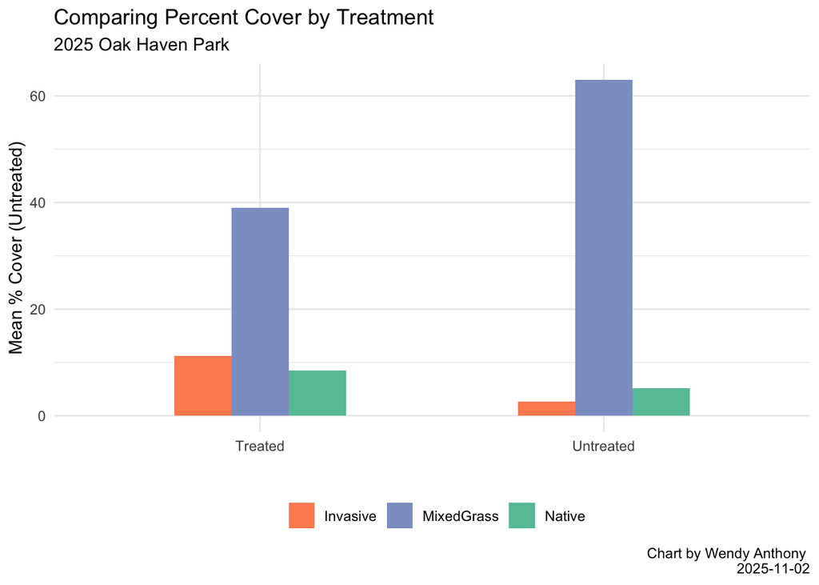

```r
# create custom colour-blind-friendly palette
custom_colours <- c("Invasive" = "#fc8d62",
                    "Native" = "#66c2a5",
                    "MixedGrass" = "#8da0cb")

compare_treat_untreat_bar <- ggplot(oakhaven_2025_cover_mean_by_group_treat, aes(Treated, mean_value, fill = Native_or_Invasive)) +
  geom_bar(stat = "identity", width = 0.5, position = "dodge") +
  # scale_fill_brewer(palette = "Dark2") +
  theme_minimal() + #get rid of grey background and tick marks
  theme(legend.position ="bottom") +
  theme(legend.title=element_blank()) +
  scale_fill_manual(values = custom_colours) +
  labs(title='Comparing Percent Cover by Treatment',
          subtitle='2025 Oak Haven Park',
          caption = "Chart by Wendy Anthony \n 2025-11-02",
          x = "", y = "Mean % Cover (Untreated)",
          # Legend Title
          fill = "Native or Invasive")

compare_treat_untreat_bar
```

```r
# ggsave(filename = paste0("images/compare_treat_untreat_bar_", format(Sys.time(), "%Y-%m-%d_%H.%M"),".png"), compare_treat_untreat_bar)
```

### 9.6.23 ** Compare Means Bar Chart Dodge no grass

```r
colnames(oakhaven_2025_cover_mean_by_group_treat)
```

```
## [1] "Treated"            "Native_or_Invasive" "mean_value"
## [4] "sd_value"
```

```r
str(oakhaven_2025_cover_mean_by_group_treat)
```

```
## gropd_df [6 × 4] (S3: grouped_df/tbl_df/tbl/data.frame)
##  $ Treated           : chr [1:6] "Treated" "Treated" "Treated" "Untreated" ...
##  $ Native_or_Invasive: chr [1:6] "Invasive" "MixedGrass" "Native" "Invasive" ...
##  $ mean_value        : num [1:6] 11.2 39 8.47 2.67 63 ...
##  $ sd_value          : num [1:6] 9.92 18.83 7.96 2.08 26.94 ...
##  - attr(*, "groups")= tibble [2 × 2] (S3: tbl_df/tbl/data.frame)
##   ..$ Treated: chr [1:2] "Treated" "Untreated"
##   ..$ .rows  : list<int> [1:2]
##   .. ..$ : int [1:3] 1 2 3
##   .. ..$ : int [1:3] 4 5 6
##   .. ..@ ptype: int(0)
##   ..- attr(*, ".drop")= logi TRUE
```

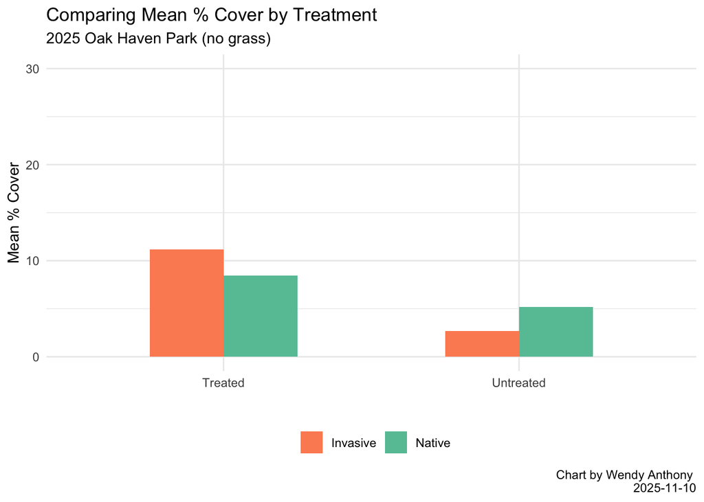

```r
# create custom colour-blind-friendly palette
custom_colours <- c("Invasive" = "#fc8d62",
                    "Native" = "#66c2a5",
                    "MixedGrass" = "#8da0cb")

compare_treat_untreat_nograss_bar <- oakhaven_2025_cover_mean_by_group_treat %>% filter(Native_or_Invasive != "MixedGrass") %>%
ggplot(aes(Treated, mean_value, fill = Native_or_Invasive)) +
  geom_bar(stat = "identity", width = 0.5, position = "dodge") +
  ylim(0, 30) +
  # scale_fill_brewer(palette = "Dark2") +
  theme_minimal() + #get rid of grey background and tick marks
  theme(legend.position ="bottom") +
  theme(legend.title=element_blank()) +
  scale_fill_manual(values = custom_colours) +
  labs(title='Comparing Mean % Cover by Treatment',
          subtitle='2025 Oak Haven Park (no grass)',
          caption = "Chart by Wendy Anthony \n 2025-11-10",
          x = "", y = "Mean % Cover",
          # Legend Title
          fill = "Native or Invasive")

compare_treat_untreat_nograss_bar
```

```r
# ggsave(filename = paste0("images/compare_treat_untreat_nograss_bar_", format(Sys.time(), "%Y-%m-%d_%H.%M"),".png"), compare_treat_untreat_nograss_bar)
```

### 9.6.24 **** Compare Means and SD by Treatment Bar Chart Dodge

```r
colnames(oakhaven_2025_cover_mean_by_group_treat)
```

```
## [1] "Treated"            "Native_or_Invasive" "mean_value"
## [4] "sd_value"
```

```r
str(oakhaven_2025_cover_mean_by_group_treat)
```

```
## gropd_df [6 × 4] (S3: grouped_df/tbl_df/tbl/data.frame)
##  $ Treated           : chr [1:6] "Treated" "Treated" "Treated" "Untreated" ...
##  $ Native_or_Invasive: chr [1:6] "Invasive" "MixedGrass" "Native" "Invasive" ...
##  $ mean_value        : num [1:6] 11.2 39 8.47 2.67 63 ...
##  $ sd_value          : num [1:6] 9.92 18.83 7.96 2.08 26.94 ...
##  - attr(*, "groups")= tibble [2 × 2] (S3: tbl_df/tbl/data.frame)
##   ..$ Treated: chr [1:2] "Treated" "Untreated"
##   ..$ .rows  : list<int> [1:2]
##   .. ..$ : int [1:3] 1 2 3
##   .. ..$ : int [1:3] 4 5 6
##   .. ..@ ptype: int(0)
##   ..- attr(*, ".drop")= logi TRUE
```

```r
colnames(oakhaven_2025_cover_mean_by_group_species)
```

```
## [1] "Species"            "Treated"            "Native_or_Invasive"
## [4] "mean_value"         "sd_value"
```

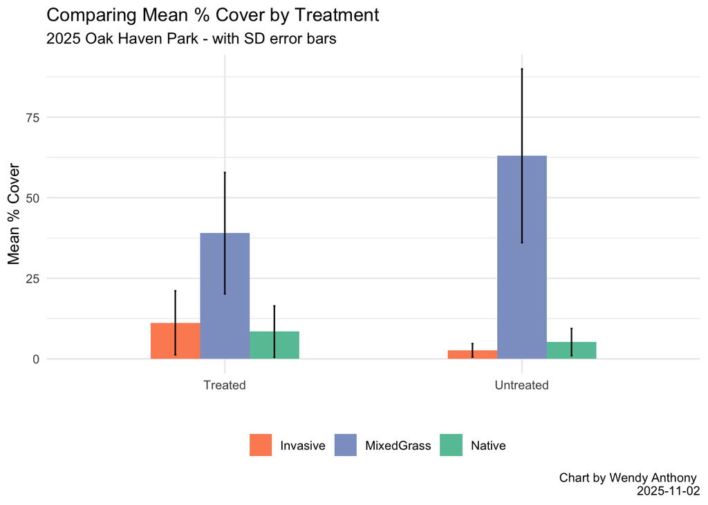

```r
# create custom colour-blind-friendly palette
custom_colours <- c("Invasive" = "#fc8d62",
                    "Native" = "#66c2a5",
                    "MixedGrass" = "#8da0cb")

# https://www.geeksforgeeks.org/r-language/plot-mean-and-standard-deviation-using-ggplot2-in-r/
compare_mean_sd_treat_untreat_bar <- ggplot(oakhaven_2025_cover_mean_by_group_treat, aes(Treated, mean_value, fill = Native_or_Invasive)) +
  geom_bar(stat = "identity", width = 0.5, position = "dodge") +
  geom_errorbar(aes(ymin = mean_value - sd_value, ymax = mean_value + sd_value), width =.02, position = position_dodge(0.5)) +
  # scale_fill_brewer(palette = "Dark2") +
  theme_minimal() + #get rid of grey background and tick marks
  theme(legend.position ="bottom") +
  theme(legend.title=element_blank()) +
  scale_fill_manual(values = custom_colours) +
  labs(title='Comparing Mean % Cover by Treatment',
          subtitle='2025 Oak Haven Park - with SD error bars',
          caption = "Chart by Wendy Anthony \n 2025-11-02",
          x = "", y = "Mean % Cover",
          # Legend Title
          fill = "Native or Invasive"
          )

compare_mean_sd_treat_untreat_bar
```

```r
# ggsave(filename = paste0("images/compare_mean_sd_treat_untreat_bar_", format(Sys.time(), "%Y-%m-%d_%H.%M"),".png"), compare_mean_sd_treat_untreat_bar)

# ggsave("images/compare_mean_sd_treat_untreat_bar.png", compare_mean_sd_treat_untreat_bar)
```

### 9.6.25 **** Compare Means and SD Bar Chart Dodge no grass

```r
colnames(oakhaven_2025_cover_mean_by_group_treat)
```

```
## [1] "Treated"            "Native_or_Invasive" "mean_value"
## [4] "sd_value"
```

```r
str(oakhaven_2025_cover_mean_by_group_treat)
```

```
## gropd_df [6 × 4] (S3: grouped_df/tbl_df/tbl/data.frame)
##  $ Treated           : chr [1:6] "Treated" "Treated" "Treated" "Untreated" ...
##  $ Native_or_Invasive: chr [1:6] "Invasive" "MixedGrass" "Native" "Invasive" ...
##  $ mean_value        : num [1:6] 11.2 39 8.47 2.67 63 ...
##  $ sd_value          : num [1:6] 9.92 18.83 7.96 2.08 26.94 ...
##  - attr(*, "groups")= tibble [2 × 2] (S3: tbl_df/tbl/data.frame)
##   ..$ Treated: chr [1:2] "Treated" "Untreated"
##   ..$ .rows  : list<int> [1:2]
##   .. ..$ : int [1:3] 1 2 3
##   .. ..$ : int [1:3] 4 5 6
##   .. ..@ ptype: int(0)
##   ..- attr(*, ".drop")= logi TRUE
```

```r
colnames(oakhaven_2025_cover_mean_by_group_species)
```

```
## [1] "Species"            "Treated"            "Native_or_Invasive"
## [4] "mean_value"         "sd_value"
```

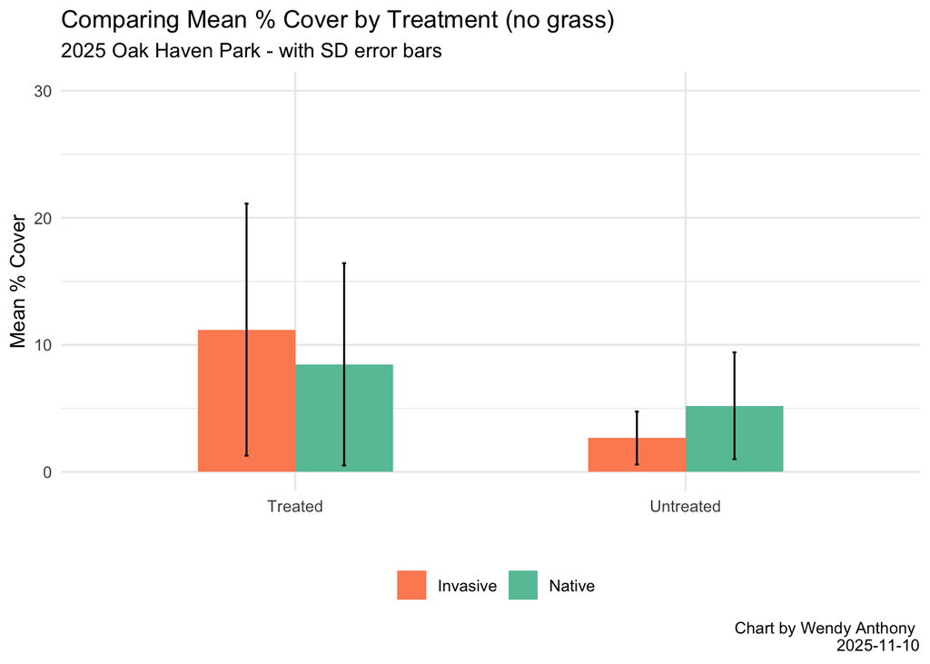

```r
# create custom colour-blind-friendly palette
custom_colours <- c("Invasive" = "#fc8d62",
                    "Native" = "#66c2a5",
                    "MixedGrass" = "#8da0cb")

# https://www.geeksforgeeks.org/r-language/plot-mean-and-standard-deviation-using-ggplot2-in-r/
compare_mean_sd_treat_untreat_nograss_bar <- oakhaven_2025_cover_mean_by_group_treat  %>% filter(Native_or_Invasive != "MixedGrass") %>%
ggplot(aes(Treated, mean_value, fill = Native_or_Invasive)) +
  geom_bar(stat = "identity", width = 0.5, position = "dodge") +
  geom_errorbar(aes(ymin = mean_value - sd_value, ymax = mean_value + sd_value), width =.02, position = position_dodge(0.5)) +
  ylim(0, 30) +
  # scale_fill_brewer(palette = "Dark2") +
  theme_minimal() + #get rid of grey background and tick marks
  theme(legend.position ="bottom") +
  theme(legend.title=element_blank()) +
  scale_fill_manual(values = custom_colours) +
  labs(title='Comparing Mean % Cover by Treatment (no grass)',
          subtitle='2025 Oak Haven Park - with SD error bars',
          caption = "Chart by Wendy Anthony \n 2025-11-10",
          x = "", y = "Mean % Cover",
          # Legend Title
          fill = "Native or Invasive"
          )

compare_mean_sd_treat_untreat_nograss_bar
```

```r
# ggsave(filename = paste0("images/compare_mean_sd_treat_untreat_nograss_bar_", format(Sys.time(), "%Y-%m-%d_%H.%M"),".png"), compare_mean_sd_treat_untreat_nograss_bar)

# ggsave("images/compare_mean_sd_treat_untreat_nograss_bar.png", compare_mean_sd_treat_untreat_nograss_bar)
```

### 9.6.26 **** Combine 2 Bar Treatment plots grass no grass

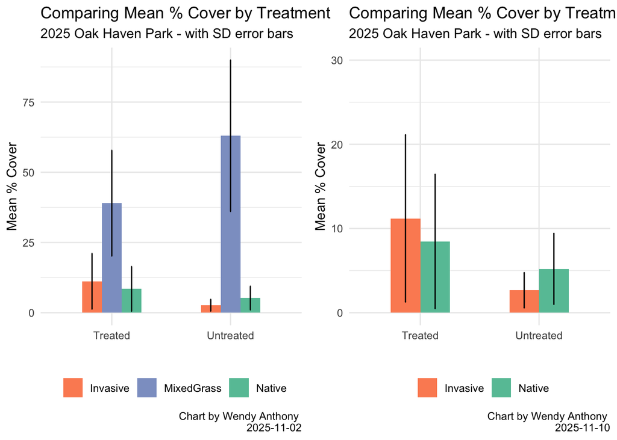

```r
# library(gridExtra)

combine_mean_sd_treat_untreat_grassnograss_bar <- grid.arrange(arrangeGrob(compare_mean_sd_treat_untreat_bar, compare_mean_sd_treat_untreat_nograss_bar, ncol = 2))
```

```r
# ggsave(filename = paste0("images/combine_mean_sd_treat_untreat_grassnograss_bar_", format(Sys.time(), "%Y-%m-%d_%H.%M"),".png"), combine_mean_sd_treat_untreat_grassnograss_bar)
```

### 9.6.27 Violin Compare all - all

```r
colnames(oakhaven_2025_cover_mean_by_group_treat)
```

```
## [1] "Treated"            "Native_or_Invasive" "mean_value"
## [4] "sd_value"
```

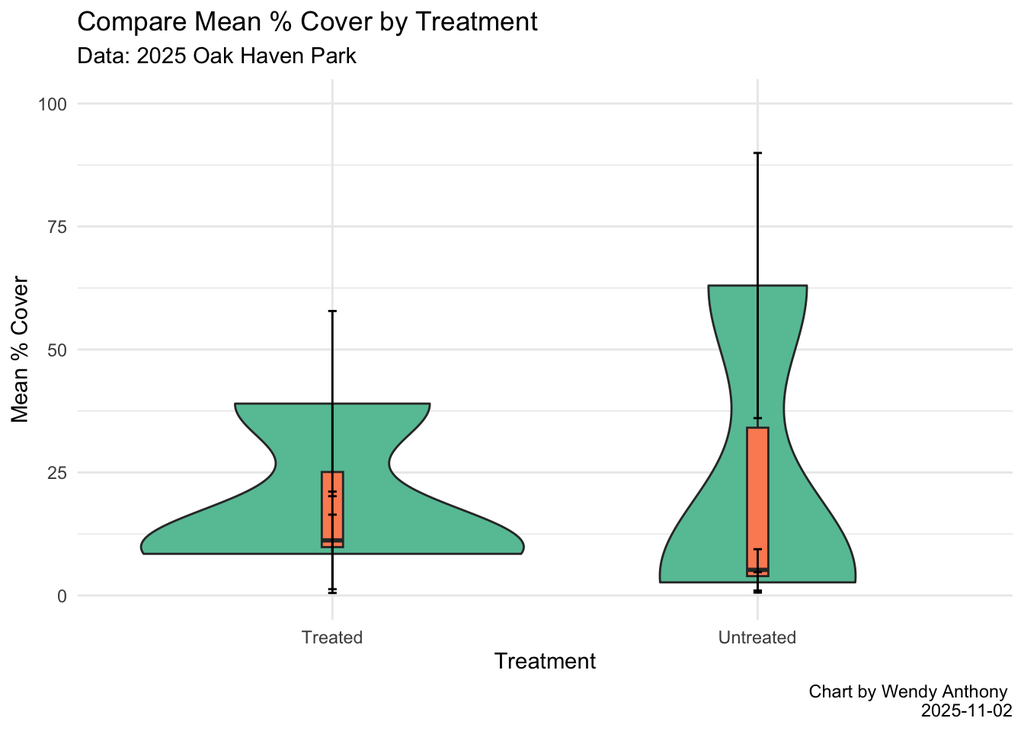

```r
oakhaven_2025_cover_mean_by_group_treat_violin <- ggplot(oakhaven_2025_cover_mean_by_group_treat,
       # text = paste("Site:", Site),
      aes(x = Treated, y = mean_value)) +
      geom_violin(fill = "#66c2a5") +
      geom_boxplot(width = 0.05, fill = "#fc8d62") +
      geom_errorbar(aes(ymin = mean_value - sd_value, ymax = mean_value + sd_value), width =.02) +
      scale_fill_brewer(palette = "Dark2") +
      theme_minimal() + #get rid of grey background and tick marks
      scale_y_continuous(limits = c(0, 100)) +
      labs(title='Compare Mean % Cover by Treatment',
           subtitle='Data: 2025 Oak Haven Park',
           caption = "Chart by Wendy Anthony \n 2025-11-02",
           x = "Treatment",
           y = "Mean % Cover")

oakhaven_2025_cover_mean_by_group_treat_violin
```

```r
# ggsave(filename = paste0("images/oakhaven_2025_cover_mean_by_group_treat_violin_", format(Sys.time(), "%Y-%m-%d_%H.%M"),".png"), oakhaven_2025_cover_mean_by_group_treat_violin)
```

### 9.6.28 Violin Compare all - no grass

```r
colnames(oakhaven_2025_cover_mean_by_group_treat)
```

```
## [1] "Treated"            "Native_or_Invasive" "mean_value"
## [4] "sd_value"
```

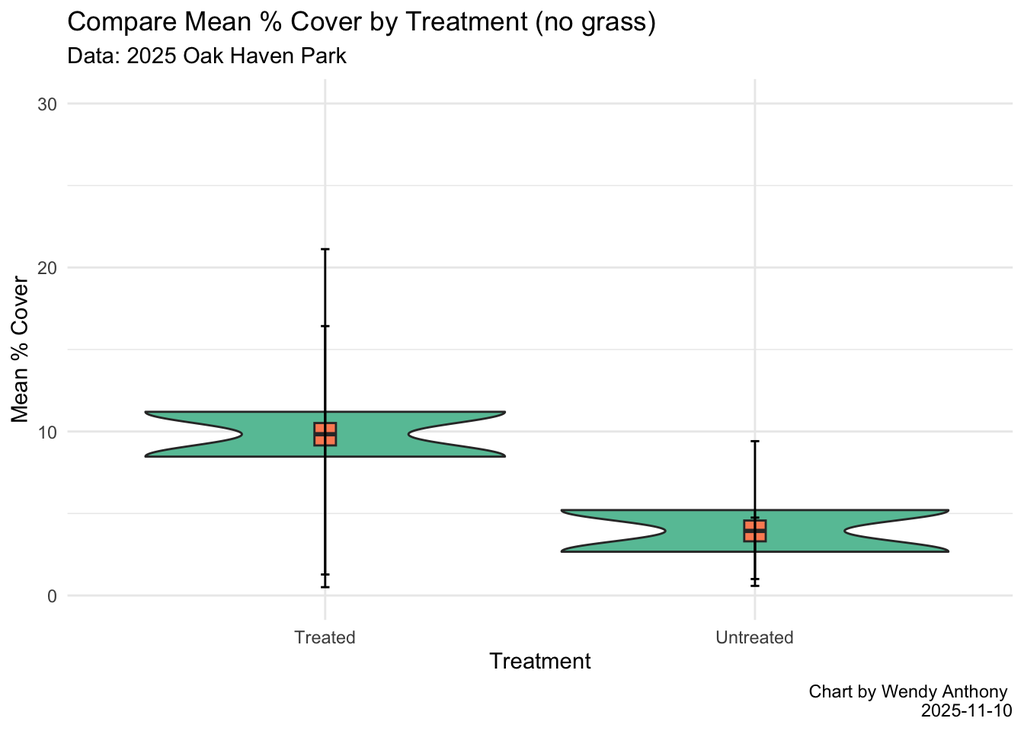

```r
oakhaven_2025_cover_mean_by_group_treat_nograss_violin <- oakhaven_2025_cover_mean_by_group_treat %>% filter(Native_or_Invasive != "MixedGrass") %>%
ggplot(
       # text = paste("Site:", Site),
      aes(x = Treated, y = mean_value)) +
      geom_violin(fill = "#66c2a5") +
      geom_boxplot(width = 0.05, fill = "#fc8d62") +
      geom_errorbar(aes(ymin = mean_value - sd_value, ymax = mean_value + sd_value), width =.02) +
      scale_fill_brewer(palette = "Dark2") +
      theme_minimal() + #get rid of grey background and tick marks
      scale_y_continuous(limits = c(0, 30)) +
      labs(title='Compare Mean % Cover by Treatment (no grass)',
           subtitle='Data: 2025 Oak Haven Park',
           caption = "Chart by Wendy Anthony \n 2025-11-10",
           x = "Treatment",
           y = "Mean % Cover")

oakhaven_2025_cover_mean_by_group_treat_nograss_violin
```

```r
# ggsave(filename = paste0("images/oakhaven_2025_cover_mean_by_group_treat_nograss_violin_", format(Sys.time(), "%Y-%m-%d_%H.%M"),".png"), oakhaven_2025_cover_mean_by_group_treat_nograss_violin)
```

# 10 Glue

https://glue.tidyverse.org/  
https://cran.r-project.org/web/packages/glue/glue.pdf

```r
library(glue)
library(crayon)
# colnames(oakhaven_2025_cover_mean_by_group_species)

glue_col("{red S}{yellow p}{green e}{cyan c}{blue i}{magenta e}{red s} {red %} {yellow M}{green e}{cyan a}{blue n} {red C}{yellow o}{green v}{cyan e}{blue r}")
```

```
## Species % Mean Cover
```

```r
glue_data(oakhaven_2025_cover_mean_by_group_species, "{Species} in {Treated} plots has a mean % cover value of {mean_value}")
```

```
## Menzies larkspur in Treated plots has a mean % cover value of 9.5
## Menzies larkspur in Untreated plots has a mean % cover value of 9
## Oregon grape in Treated plots has a mean % cover value of 21.5
## Oregon grape in Untreated plots has a mean % cover value of 11
## Pacific sanicle in Treated plots has a mean % cover value of 1.66666666666667
## Scotch broom in Treated plots has a mean % cover value of 2
## Scotch broom in Untreated plots has a mean % cover value of 3.5
## camas in Treated plots has a mean % cover value of 7.5
## camas in Untreated plots has a mean % cover value of 5.6
## delphinium in Treated plots has a mean % cover value of 9
## delphinium in Untreated plots has a mean % cover value of 3
## fawn lily in Treated plots has a mean % cover value of 1.6
## fawn lily in Untreated plots has a mean % cover value of 3
## field chickweed in Treated plots has a mean % cover value of 3
## field chickweed in Untreated plots has a mean % cover value of 1.5
## herb robert geranium in Treated plots has a mean % cover value of 6.5
## mixed grass in Treated plots has a mean % cover value of 34.25
## mixed grass in Untreated plots has a mean % cover value of 70.75
## mixed invasive grasses in Untreated plots has a mean % cover value of 53
## mixed moss and grass in Treated plots has a mean % cover value of 48.5
## mixed moss and grass in Untreated plots has a mean % cover value of 52.5
## moss in Treated plots has a mean % cover value of 16
## moss in Untreated plots has a mean % cover value of 8
## onion in Untreated plots has a mean % cover value of 1
## rose in Untreated plots has a mean % cover value of 1
## saxifrage species in Treated plots has a mean % cover value of 1
## shiny geranium in Treated plots has a mean % cover value of 15.8333333333333
## shooting star in Treated plots has a mean % cover value of 11
## shooting star in Untreated plots has a mean % cover value of 3.25
## snowberry in Treated plots has a mean % cover value of 11.6666666666667
## snowberry in Untreated plots has a mean % cover value of 11
## speedwell in Untreated plots has a mean % cover value of 1
```

```r
#  add color
# glue_data_col(oakhaven_2025_cover_mean_by_group_species, "{yellow {Species}} in {magenta {Treated}} plots has a mean % cover value of {blue {mean_value}}")

# add bold and italic
# NOTE these colours and bold and italic formatting do NOT KNIT !! ;(
glue_data_col(oakhaven_2025_cover_mean_by_group_species, "{bold {yellow {Species}}} in {italic {magenta {Treated}}} plots has a mean % cover value of {blue {mean_value}}")
```

```
## Menzies larkspur in Treated plots has a mean % cover value of 9.5
## Menzies larkspur in Untreated plots has a mean % cover value of 9
## Oregon grape in Treated plots has a mean % cover value of 21.5
## Oregon grape in Untreated plots has a mean % cover value of 11
## Pacific sanicle in Treated plots has a mean % cover value of 1.66666666666667
## Scotch broom in Treated plots has a mean % cover value of 2
## Scotch broom in Untreated plots has a mean % cover value of 3.5
## camas in Treated plots has a mean % cover value of 7.5
## camas in Untreated plots has a mean % cover value of 5.6
## delphinium in Treated plots has a mean % cover value of 9
## delphinium in Untreated plots has a mean % cover value of 3
## fawn lily in Treated plots has a mean % cover value of 1.6
## fawn lily in Untreated plots has a mean % cover value of 3
## field chickweed in Treated plots has a mean % cover value of 3
## field chickweed in Untreated plots has a mean % cover value of 1.5
## herb robert geranium in Treated plots has a mean % cover value of 6.5
## mixed grass in Treated plots has a mean % cover value of 34.25
## mixed grass in Untreated plots has a mean % cover value of 70.75
## mixed invasive grasses in Untreated plots has a mean % cover value of 53
## mixed moss and grass in Treated plots has a mean % cover value of 48.5
## mixed moss and grass in Untreated plots has a mean % cover value of 52.5
## moss in Treated plots has a mean % cover value of 16
## moss in Untreated plots has a mean % cover value of 8
## onion in Untreated plots has a mean % cover value of 1
## rose in Untreated plots has a mean % cover value of 1
## saxifrage species in Treated plots has a mean % cover value of 1
## shiny geranium in Treated plots has a mean % cover value of 15.8333333333333
## shooting star in Treated plots has a mean % cover value of 11
## shooting star in Untreated plots has a mean % cover value of 3.25
## snowberry in Treated plots has a mean % cover value of 11.6666666666667
## snowberry in Untreated plots has a mean % cover value of 11
## speedwell in Untreated plots has a mean % cover value of 1
```

```r
# # filter for native and treated
 oakhaven_2025_cover_mean_by_group_species_native_treated <- oakhaven_2025_cover_mean_by_group_species %>% filter(Native_or_Invasive == "Native") %>% filter(Treated == "Treated")
#
# glue_data(oakhaven_2025_cover_mean_by_group_species_native_treated, "{Species} in treated plots has a mean % cover value of {mean_value}")
```

## 10.1 Text with mean value

- this creates a new column with glued-text

```r
oakhaven_2025_cover_mean_by_group_species
```

```
## # A tibble: 32 × 5
## # Groups:   Species, Treated [32]
##    Species          Treated   Native_or_Invasive mean_value sd_value
##    <chr>            <chr>     <chr>                   <dbl>    <dbl>
##  1 Menzies larkspur Treated   Native                   9.5     0.707
##  2 Menzies larkspur Untreated Native                   9       5.66
##  3 Oregon grape     Treated   Native                  21.5    19.1
##  4 Oregon grape     Untreated Native                  11       2.65
##  5 Pacific sanicle  Treated   Native                   1.67    1.15
##  6 Scotch broom     Treated   Invasive                 2       1.41
##  7 Scotch broom     Untreated Invasive                 3.5     2.12
##  8 camas            Treated   Native                   7.5     3.79
##  9 camas            Untreated Native                   5.6     4.34
## 10 delphinium       Treated   Native                   9       1.41
## # ℹ 22 more rows
```

```r
oakhaven_2025_cover_mean_by_group_species_nat <- oakhaven_2025_cover_mean_by_group_species %>% filter(Native_or_Invasive == "Native")

# maxval <- max(oakhaven_2025_cover_mean_by_group_species_nat$mean_value, na.rm = TRUE)
#
# glue_data(maxval, "{Species} in {Treated} plots has a mean % cover value of {mean_value}")

annot_max <- oakhaven_2025_cover_mean_by_group_species |>
  dplyr::slice_max(order_by = mean_value) |>
  dplyr::mutate(label = glue("In {Treated} areas the mean % cover of {Species} is {mean_value}")) |>
  dplyr::select(Species, mean_value, label)
annot_max
```

```
## # A tibble: 32 × 4
## # Groups:   Species, Treated [32]
##    Treated   Species          mean_value label
##    <chr>     <chr>                 <dbl> <glue>
##  1 Treated   Menzies larkspur       9.5  In Treated areas the mean % cover of M…
##  2 Untreated Menzies larkspur       9    In Untreated areas the mean % cover of…
##  3 Treated   Oregon grape          21.5  In Treated areas the mean % cover of O…
##  4 Untreated Oregon grape          11    In Untreated areas the mean % cover of…
##  5 Treated   Pacific sanicle        1.67 In Treated areas the mean % cover of P…
##  6 Treated   Scotch broom           2    In Treated areas the mean % cover of S…
##  7 Untreated Scotch broom           3.5  In Untreated areas the mean % cover of…
##  8 Treated   camas                  7.5  In Treated areas the mean % cover of c…
##  9 Untreated camas                  5.6  In Untreated areas the mean % cover of…
## 10 Treated   delphinium             9    In Treated areas the mean % cover of d…
## # ℹ 22 more rows
```

# 11 Leaflet Maps

## 11.1 3-Site Map

```r
# library(dplyr)
library(leaflet)

# Title control
# (Shackelford, et al., 2024). Global Restore Project. Restoration Futures Lab at the University of Victoria
     title <- '<p style="text-align: center; height: 18px; "><img src="https://images.squarespace-cdn.com/content/v1/5e3c5b7e5460c55405a6d4d6/a8c2fb30-96fd-4042-925f-e76c7040dce6/Black+Logo+2.png?format=5w"><span style="font-size:9px;font-weight:bold; background-color: rgba(255, 255, 255, 0.9;");>GOE Monitoring Covenant Sites Map</span></p>'

    # https://rstudio.github.io/leaflet/articles/markers.html
    # Create a palette that maps factor levels to colors
    #####
 # #d95f02 orange; #7570b3 purple; #1b9e77
     # https://colorbrewer2.org/#type=qualitative&scheme=Dark2&n=5
    pal <- colorFactor(c("#1b9e77", "#7570b3", "#d95f02", "#e7298a", "#66a61e"), domain = c("Central Saanich", "Colwood", "Esquimalt", "Saanich", "Metchosin"))
HAT_sites_map  <-  leaflet(HAT_sites) %>%
      addProviderTiles("Esri.WorldImagery") %>%
      addCircleMarkers(
        ~ Lng, ~ Lat,
        #
        color = ~pal(Municipality),
        # color = "yellow",
        weight = 1, # size of circle border
        stroke = TRUE, fillOpacity = 1, #fillOpacity = 0.5
        radius = 5,
        # OM_site_data$
        # "<b>Global Restore Project GOE Monitoring Sites</b>", "<br>", "<i>(Shackelford, et. al., 2005-2022)</i>", "<br><br>",
        popup = paste0(
        "<img src = 'https://images.squarespace-cdn.com/content/v1/5e3c5b7e5460c55405a6d4d6/a8c2fb30-96fd-4042-925f-e76c7040dce6/Black+Logo+2.png?format=5w'>",  "<br>","<br>",
          "<b>Site:</b> ", "<b>", HAT_sites$Site, "</b>",  "<br>",
          "<b>Municipality:</b> ", HAT_sites$Municipality, "<br>",
          "<b>Size:</b> ", HAT_sites$Size_ha, " (ha)", "<br>",
          "<b>First Nations:</b> ", HAT_sites$FirstNations, "<br>",
          # "<b>Project id:</b> ", HAT_sites$ID, "<br>",
          "<b>HAT Status:</b> ", HAT_sites$HAT_Status, "<br>",
          "<b>Co-Covenant:</b> ", HAT_sites$Co_Covenant, " (", HAT_sites$Date, ")", "<br>",
          "<b>Ecosystems:</b> ", HAT_sites$Ecosystems, "<br>",
          "<b>Volunteer Stewardship:</b> ", HAT_sites$Volunteer_Stewardship, "<br>"
          ))  %>%
      addLegend("bottomright", pal = pal, values = HAT_sites$Municipality, title = "Municipality") %>%

      setView(-123.44799, 48.52919, 11) %>%
      # add controls
      #  addMiniMap(width = 150, height = 150, zoomLevelOffset = -4) %>%
      addControl(title, position = "topright")

# Display map
HAT_sites_map
```

[interactive chart not shown]

```r
# Save map
saveWidget(HAT_sites_map, "output/HAT_site_map.html")
```

# 12 Session Info

- to document specific packages used to run script

sessionInfo()